# CSCI E-63C: Week 3 Assignment

Tony McGovern

19 September 2017

# Problem 1

In this problem, I load, model, visualize, and comment on data that predicts abalone snail age as a function of other physical attributes.

```r
# load data
url <- "http://archive.ics.uci.edu/ml/machine-learning-databases/abalone/abalone.data"
#url <- "/Users/Luxive/OneDrive/Software_Engineering/Harvard/CSCI E-63c/HW/abalone.data"
abalone.raw <- read_delim(url, ",", col_names = c("sex","length","diameter","height","weight.whole","weight.shucked","weight.viscera","weight.shell","rings"))
```

Describe the data set attributes:

| col_name | attribute_name |
| --- | --- |
| sex | Sex |
| length | Length |
| diameter | Diameter |
| height | Height |
| weight.whole | Whole Weight |
| weight.shucked | Shucked Weight |
| weight.viscera | Viscera Weight |
| weight.shell | Shell Weight |
| rings | Rings |

The `abalone` data set has 4177 rows or observations and 9 columns or variables. The predictor variables are *sex*, *length*, *diameter*, *height*, *weight.whole*, *weight.shucked*, *weight.viscera*, and *weight.shell*. The response variable is *rings*. The *sex* variable is a categorical dimension with three distinct values: “F”, “I”, and “M”. All other variables are continuous variables.

## Correlations

The following chunk creates a Pearson correlation matrix:

```r
# convert 'sex' variable from a character to a factor
abalone.raw$sex <- factor(abalone.raw$sex)

# convert 'rings' variable from an int to a numeric
abalone.raw$rings <- as.numeric(abalone.raw$rings)

# create 'age' variable which represents the snail age equal to rings + 1.5 per data set description
# drop 'rings' variable
abalone.age <- abalone.raw %>% mutate( age = rings + 1.5 ) %>% select( -c(rings) )

# drop categorical 'sex' variable
abalone.cont <- abalone.age %>% select(-c(sex))

# create Pearson correlation matrix
correlations.pearson <- cor(abalone.cont, method = c("pearson"))
kable(correlations.pearson)
```

|  | length | diameter | height | weight.whole | weight.shucked | weight.viscera | weight.shell | age |
| --- | --- | --- | --- | --- | --- | --- | --- | --- |
| length | 1.0000000 | 0.9868116 | 0.8275536 | 0.9252612 | 0.8979137 | 0.9030177 | 0.8977056 | 0.5567196 |
| diameter | 0.9868116 | 1.0000000 | 0.8336837 | 0.9254521 | 0.8931625 | 0.8997244 | 0.9053298 | 0.5746599 |
| height | 0.8275536 | 0.8336837 | 1.0000000 | 0.8192208 | 0.7749723 | 0.7983193 | 0.8173380 | 0.5574673 |
| weight.whole | 0.9252612 | 0.9254521 | 0.8192208 | 1.0000000 | 0.9694055 | 0.9663751 | 0.9553554 | 0.5403897 |
| weight.shucked | 0.8979137 | 0.8931625 | 0.7749723 | 0.9694055 | 1.0000000 | 0.9319613 | 0.8826171 | 0.4208837 |
| weight.viscera | 0.9030177 | 0.8997244 | 0.7983193 | 0.9663751 | 0.9319613 | 1.0000000 | 0.9076563 | 0.5038192 |
| weight.shell | 0.8977056 | 0.9053298 | 0.8173380 | 0.9553554 | 0.8826171 | 0.9076563 | 1.0000000 | 0.6275740 |
| age | 0.5567196 | 0.5746599 | 0.5574673 | 0.5403897 | 0.4208837 | 0.5038192 | 0.6275740 | 1.0000000 |

The following chunk creates a Pearson correlation plot:

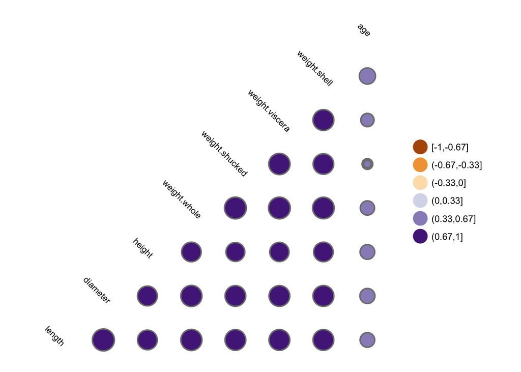

```r
# visualize pearson correlation matrix
#corrplot(correlations.pearson, order = "hclust")

# pearson pairwise correlations
ggcorr(
  data = abalone.cont,
  #label = TRUE,
  method = c("pairwise", "pearson"),
  label_alpha = TRUE,
  geom = "circle",
  max_size = 10,
  min_size = 2,
  size = 3,
  hjust = 0.75,
  nbreaks = 6,
  angle = -45,
  palette = "PuOr"
)
```

The following chunk creates a Spearman correlation matrix:

```r
# create Spearman correlation matrix
correlations.spearman <- cor(abalone.cont, method = c("spearman"))
kable(correlations.spearman)
```

|  | length | diameter | height | weight.whole | weight.shucked | weight.viscera | weight.shell | age |
| --- | --- | --- | --- | --- | --- | --- | --- | --- |
| length | 1.0000000 | 0.9833190 | 0.8882060 | 0.9726329 | 0.9568303 | 0.9526577 | 0.9479264 | 0.6043853 |
| diameter | 0.9833190 | 1.0000000 | 0.8957053 | 0.9713244 | 0.9504722 | 0.9483906 | 0.9541488 | 0.6228950 |
| height | 0.8882060 | 0.8957053 | 1.0000000 | 0.9159848 | 0.8741960 | 0.9005869 | 0.9212243 | 0.6577164 |
| weight.whole | 0.9726329 | 0.9713244 | 0.9159848 | 1.0000000 | 0.9770596 | 0.9752517 | 0.9694259 | 0.6308320 |
| weight.shucked | 0.9568303 | 0.9504722 | 0.8741960 | 0.9770596 | 1.0000000 | 0.9476354 | 0.9177305 | 0.5394200 |
| weight.viscera | 0.9526577 | 0.9483906 | 0.9005869 | 0.9752517 | 0.9476354 | 1.0000000 | 0.9381434 | 0.6143438 |
| weight.shell | 0.9479264 | 0.9541488 | 0.9212243 | 0.9694259 | 0.9177305 | 0.9381434 | 1.0000000 | 0.6924746 |
| age | 0.6043853 | 0.6228950 | 0.6577164 | 0.6308320 | 0.5394200 | 0.6143438 | 0.6924746 | 1.0000000 |

The following chunk creates a Spearman correlation plot:

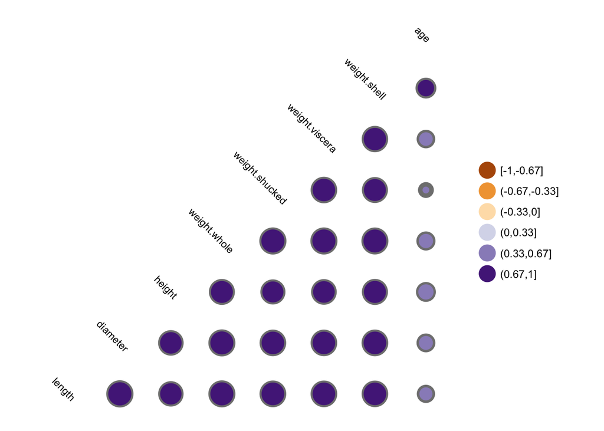

```r
# visualize spearman correlation matrix
#corrplot(correlations.spearman, order = "hclust")

# spearman pairwise correlations
ggcorr(
  data = abalone.cont,
  #label = TRUE,
  method = c("pairwise", "spearman"),
  label_alpha = TRUE,
  geom = "circle",
  max_size = 10,
  min_size = 2,
  size = 3,
  hjust = 0.75,
  nbreaks = 6,
  angle = -45,
  palette = "PuOr"
)
```

## Model

The following chunk fits a linear model of `age` as an outcome of `weight.shell` as the predictor variable using the R function `lm`. I display the model summary results below:

```r
#Fit linear model of age as outcome and shell weight as predictor using R function lm
model.linear <- lm(age ~ weight.shell, data = abalone.age)

#display the result using summary function, use its output to answer the following questions:
summary(model.linear)
```

```
##
## Call:
## lm(formula = age ~ weight.shell, data = abalone.age)
##
## Residuals:
##     Min      1Q  Median      3Q     Max
## -5.9830 -1.6005 -0.5843  0.9390 15.6334
##
## Coefficients:
##              Estimate Std. Error t value Pr(>|t|)
## (Intercept)   7.96212    0.07715  103.21   <2e-16 ***
## weight.shell 14.53568    0.27908   52.08   <2e-16 ***
## ---
## Signif. codes:  0 '***' 0.001 '**' 0.01 '*' 0.05 '.' 0.1 ' ' 1
##
## Residual standard error: 2.51 on 4175 degrees of freedom
## Multiple R-squared:  0.3938, Adjusted R-squared:  0.3937
## F-statistic:  2713 on 1 and 4175 DF,  p-value: < 2.2e-16
```

## Model Summary Discussion

The `weight.shell` predictor is significant given that the *p* value is essentially zero, suggesting that this variable explains a significant amount of variability in the `age` response variable.

The model $RSE$ is 2.5104996. The model $R^2$ is 0.3938492.

The y-intercept term is the expected value of *Y* when *X* = 0. The y-intercept in this case means that for an average shell weight of zero grams, the snail age would be about 8 years. This isn’t particularly meaningful as abalone snails should have a non-zero shell weight. In this case, the y-intercept is merely an adjustment constant that serves to adjust the line height of the linear model.

The coefficient for the `weight.shell` predictor variable is 14.5357, which means that for every one gram increase in shell weight, the `age` variable changes by about 14.5 years.

## Model Plot

The following graph shows the linear relationship between abalone age in years and shell weight in grams, with observations grouped by sex as shown by the distinct colors.

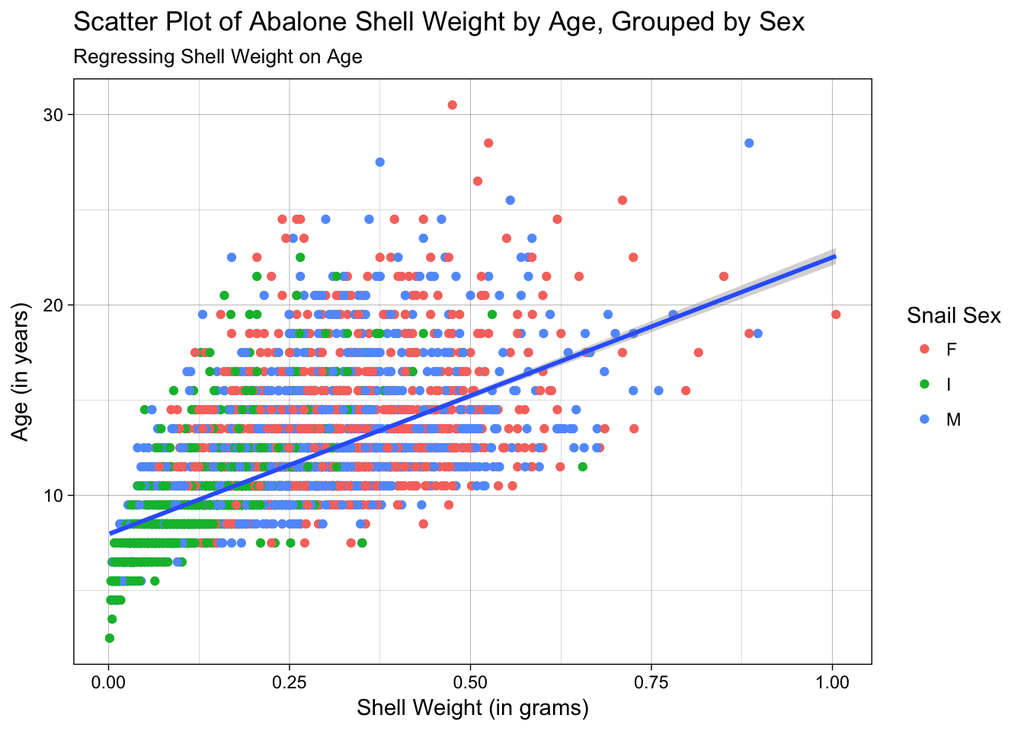

```r
#Create scatterplot of age and shell weight and add regression line from the model to the plot
ggplot( data = abalone.age, aes( x = weight.shell, y = age )) +
  geom_point( aes(color = sex )) +
  geom_smooth( method="lm", formula = y ~ x ) +
  labs(
    title = "Scatter Plot of Abalone Shell Weight by Age, Grouped by Sex",
    subtitle = "Regressing Shell Weight on Age",
    x = "Shell Weight (in grams)",
    y = "Age (in years)",
    color = "Snail Sex"
  ) +
  theme_linedraw()
```

## Model Diagnostics Discussion

The following four graphs are useful in evaluating model fit to the data. These graphs help illustrate how well OLS regression assumptions are being met:

- *Normality*
  - The “Normal Q-Q Plot”" is a probability distribution of the standardized residuals against values needed under the condition of normality. In other words, the residual values should also be normally distributed with a mean of zero. Points not on the 45° line do not follow the normality assumption, which many points in this model do not.
- *Independence*
  - Unfortunately, these diagnostic plots bear no information on whether the dependent variables are independent. In other words, there is no way to know from the data if the shell weight of one abalone snail affects the shell weight of another.
- *Linearity*
  - If the dependent variable shows some sort of linear relationship to the response variable, then the “Residuals vs Fitted” plot should show that the model captures the variance in the data and that residuals show have a random pattern. It seems as there may be non-linear, curved relationship between `age` and `weight.shell`, suggesting that a tranformation of one or both of the variables may help. Compared to the scatterplot with the OLS line shown above, it has a negative slope and a slight curve, as mentioned above.
- *Homoscedasticity*
  - OLS regressions assume the error term has a constant variance. Meeting this requirement would have the points in the “Scale-Location” plot form randomly around the horizontal line. There seems to be some regularity of the squared standardized residuals suggesting that the model does not have a constant variance. Additionally, non-constant variances in the errors can be determined from the presence of a funnel shape from the residual plot. In fact, as the value of the response gets higher, the more the residual plot takes the form a funnel in the “Residuals vs Fitted” plot.

The “Residuals vs Leverage” plot highlights points that may be outliers or high leverage points.

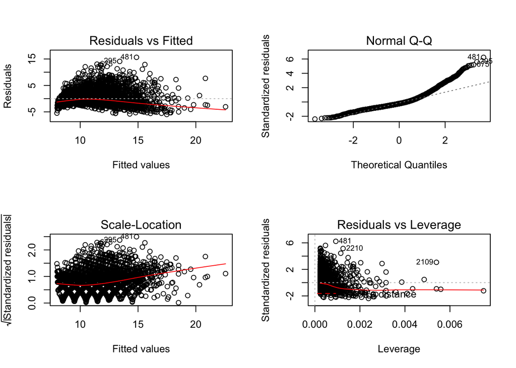

```r
opar <- par(no.readonly=TRUE)
par(mfrow=c(2,2))

#Create diagnostic plots of the model
plot(model.linear)
```

The following chunk shows the confidence interval on model parameters:

```r
#Use function confint to obtain confidence intervals on model parameters
confint(model.linear)
```

```
##                  2.5 %    97.5 %
## (Intercept)   7.810869  8.113365
## weight.shell 13.988525 15.082825
```

The following chunk uses the linear model to make predictions for new `weight.shell` values. It uses both the `confidence` and `prediction` attributes of the R `predict` function to obtain confidence and prediction intervals, respectively:

```r
#Use this model and predict function to make predictions for shell weight values of 0.1, 0.2 and 0.3.
#Use confidence and prediction settings for parameter interval in the call to predict to obtain confidence and prediction intervals on these model predictions.
predict(model.linear, data.frame(weight.shell = c(0.1, 0.2, 0.3)), interval = 'confidence')
```

```
##         fit       lwr       upr
## 1  9.415684  9.308121  9.523247
## 2 10.869252 10.790188 10.948315
## 3 12.322819 12.239634 12.406005
```

```r
predict(model.linear, data.frame(weight.shell = c(0.1, 0.2, 0.3)), interval = 'prediction')
```

```
##         fit      lwr      upr
## 1  9.415684 4.492593 14.33878
## 2 10.869252 5.946701 15.79180
## 3 12.322819 7.400201 17.24544
```

## Model Fit Discussion

To assess how accurate the coefficient estimate, $\beta_1$ – the coefficient of the model parameter `weight.shell` – is to the true population coefficient, standard errors are used to compute confidence intervals for $\beta_1$. From 3.1.2 of *ISLR*:

> A 95% confidence interval is defined as a range of values such that with 95% interval probability, the range will contain the true unknown value of the parameter. The range is defined in terms of lower and upper limits computed from the sample of data.

To assess how accurate the predicted response estimate is if an individual response that factors *irreducible error*, we use prediction intervals on model predictions. To assess how accurate the predicted response estimate is *on average*, we use confidence intervals on model predictions. From ISLR:

> Prediction intervals will always be wider than confidence intervals because they account for the uncertainty associated with *irreducible error*.

# Problem 2

## Model

In this problem, I use `lm()` to fit a regression model of *log-transformed* `age` as linear function of *log-transformed* `weight.shell`. I produce a summary of the model outputs, compare fits to previous outputs, graph the model, and produce and comment on diagnostic plots of model results.

```r
#Use lm() to fit a regression model of log-transformed age as linear function of log-transformed shell weight and use summary to evaluate its results.

# create new tibble with log-transformed age and shell weight
abalone.log.shell <- abalone.age %>%
  mutate(lage = log2(age), lshell = log2(weight.shell))

model.shell.log <- lm(lage ~ lshell, data = abalone.log.shell)

summary(model.shell.log)
```

```
##
## Call:
## lm(formula = lage ~ lshell, data = abalone.log.shell)
##
## Residuals:
##      Min       1Q   Median       3Q      Max
## -0.77387 -0.18841 -0.05452  0.14147  1.14302
##
## Coefficients:
##             Estimate Std. Error t value Pr(>|t|)
## (Intercept) 4.049690   0.009582  422.62   <2e-16 ***
## lshell      0.243920   0.003574   68.25   <2e-16 ***
## ---
## Signif. codes:  0 '***' 0.001 '**' 0.01 '*' 0.05 '.' 0.1 ' ' 1
##
## Residual standard error: 0.2704 on 4175 degrees of freedom
## Multiple R-squared:  0.5273, Adjusted R-squared:  0.5272
## F-statistic:  4657 on 1 and 4175 DF,  p-value: < 2.2e-16
```

## Model Summary Discussion

We should not compare fits obtained from using untransformed and *log-transformed* attributes since the outcome of the *log-transformed* model is no longer a linear function of regressing `weight.shell` on `age`. As stated in ISLR 3.1.3:

> The quality of a linear regression fit is typically assessed using two related quantities: the residual standard error ($RSE$) and the $R^2$.

Given that the *log-transformed* variables are no longer linearly related, it would be not be advisable to compare either the $RSE$ or the $R^2$ between the untransformed and *log-transformed* models.

A common interpretation of *log-transformed* variables, as I have done above, is that of a *percent change*.

## Model Plot

The following creates a XY-scatterplot of *log-transformed* predictor and response and adds a corresponding regression line to it:

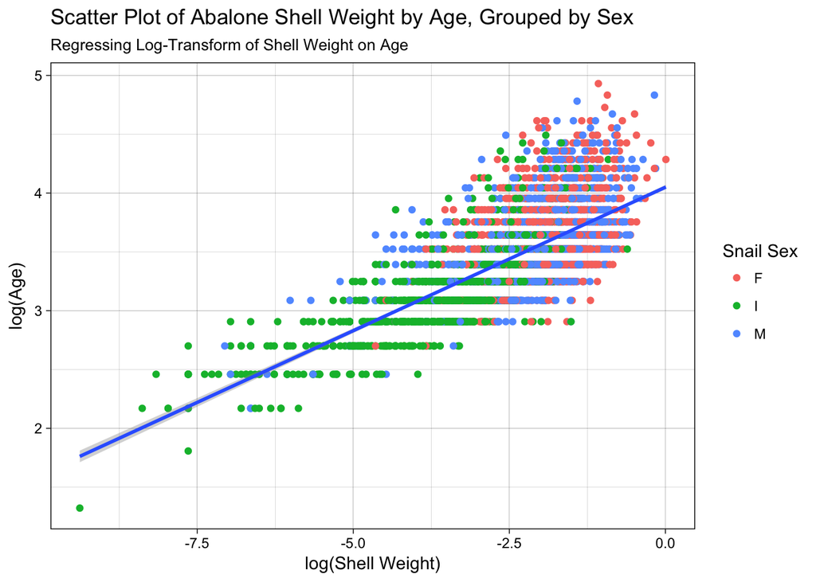

```r
#Create a XY-scatterplot of log-transformed predictor and response and add corresponding regression line to it.
ggplot( data = abalone.log.shell, aes( x = lshell, y = lage )) +
  geom_point( aes(color = sex )) +
  geom_smooth( method="lm", formula = y ~ x ) +
  labs(
    title = "Scatter Plot of Abalone Shell Weight by Age, Grouped by Sex",
    subtitle = "Regressing Log-Transform of Shell Weight on Age",
    x = "log(Shell Weight)",
    y = "log(Age)",
    color = "Snail Sex"
  ) +
  theme_linedraw()
```

Compared to the untransformed plot above, the *log-transformed* plot shows a more better, more linearly-related fit to the data. Using a *log-transform* on both the predictor and response variables gets us closer to establishing a better relationship between `weight.shell` and `age`.

The chunk below makes diagnostic plots for model fit on *log-transformed* predictor and response variables:

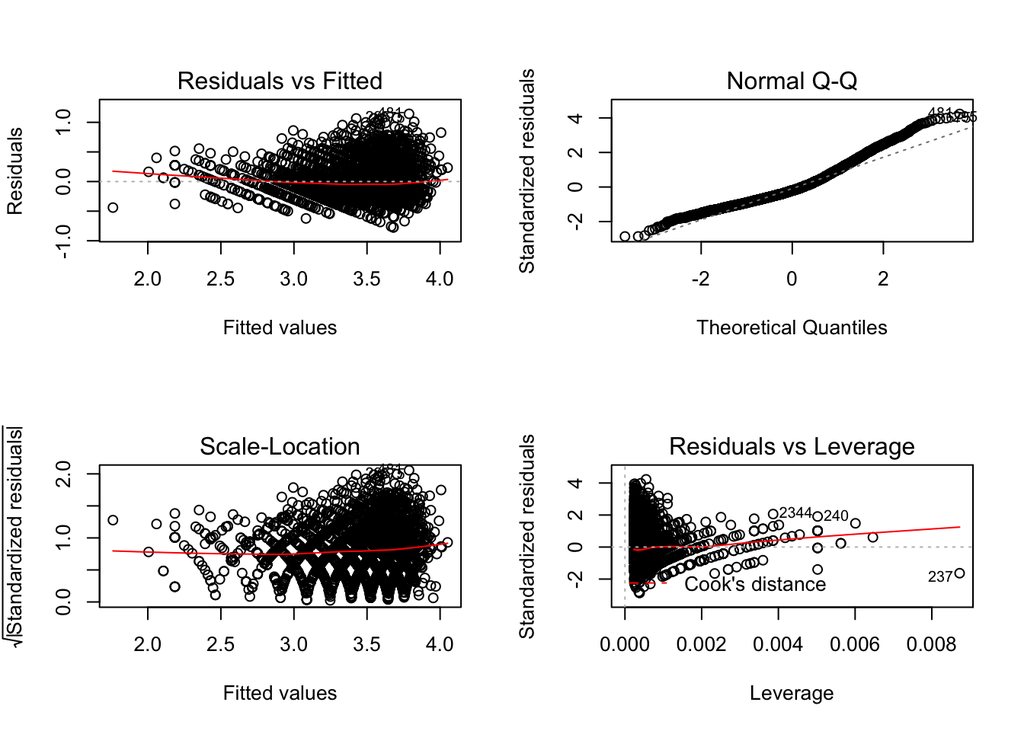

```r
opar <- par(no.readonly=TRUE)
par(mfrow=c(2,2))

#Make diagnostic plots for model fit on log-transformed age and shell weight.
plot(model.shell.log)
```

## Model Diagnostics Discussion

While many of the same features are present in the diagnostic plots of the untransformed linear model, the *log-transformed* “Residuals vs Fitted” plot shows less of a funnel shape and a close to linear relationship between the predictor and response variables, indicating a lower systematic relationship between residuals and predicted values.

The “Normal Q-Q” plot still shows that many of the residual values are still not normally distributed with a mean of 0. But there are more values on the 45° line than before. The “Scale-Location” plot, on the other hand, is much like it was before: there still seems to be some regularity of the squared standardized residuals, suggesting that the model still does not have a constant variance.

Finally, the diagnostic plots seem to indicate the the *log-transform* model improves a bit over the untransformed model but still does not meet certain assumptions about OLS regressions, namely *Normality* and *Homoscedasticity*. Perhaps adding more variables to the model may help.

# Problem 3

## Model

In this problem, I explore effects of adding another variable to the model, continue using *log-transformed* attributes and fit a model of *log-transformed* age as a function of shell weight and shucked weight (both log-transformed also).

```r
#To explore effects of adding another variable to the model, continue using log-transformed attributes and fit a model of log-transformed age as a function of shell weight and shucked weight (both log-transformed also).
abalone.log.shucked <- abalone.log.shell %>%
  mutate(lshucked = log2(weight.shucked))

model.shucked.log <- lm(lage ~ lshell + lshucked, data = abalone.log.shucked)
```

I obtain and evaluate the summary of this model fit:

```r
# obtain and evaluate the summary of this model fit
summary(model.shucked.log)
```

```
##
## Call:
## lm(formula = lage ~ lshell + lshucked, data = abalone.log.shucked)
##
## Residuals:
##      Min       1Q   Median       3Q      Max
## -1.71304 -0.16548 -0.03269  0.13136  1.14385
##
## Coefficients:
##             Estimate Std. Error t value Pr(>|t|)
## (Intercept)  4.22234    0.01069  395.14   <2e-16 ***
## lshell       0.54430    0.01110   49.05   <2e-16 ***
## lshucked    -0.29630    0.01046  -28.33   <2e-16 ***
## ---
## Signif. codes:  0 '***' 0.001 '**' 0.01 '*' 0.05 '.' 0.1 ' ' 1
##
## Residual standard error: 0.2477 on 4174 degrees of freedom
## Multiple R-squared:  0.6035, Adjusted R-squared:  0.6033
## F-statistic:  3177 on 2 and 4174 DF,  p-value: < 2.2e-16
```

## Model Summary Discussion

The following chunk shows the confidence interval on model parameters:

```r
#Use function confint to obtain confidence intervals on model parameters
confint(model.shucked.log)
```

```
##                  2.5 %     97.5 %
## (Intercept)  4.2013935  4.2432926
## lshell       0.5225392  0.5660546
## lshucked    -0.3168073 -0.2757926
```

The following chunk presents the model diagnostic plots:

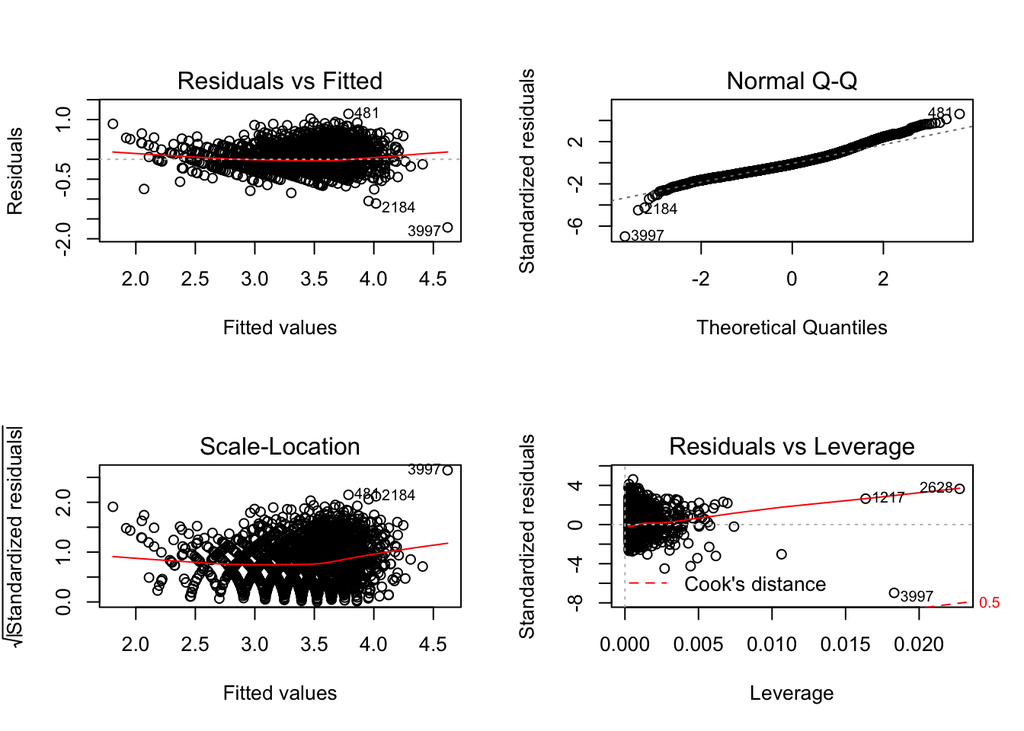

```r
opar <- par(no.readonly=TRUE)
par(mfrow=c(2,2))

#Where applicable, compare them to the model obtained above and reflect on pros and cons of including shucked weight as another variable into the model.
plot(model.shucked.log)
```

## Model Diagnostics Discussion

Adding the `weight.shucked` variable to the *log-transformed* model seems to ameliorate many of the issues in both the single-variable untransformed and *log-transformed* models.

Namely, the “Residuals vs Fitted” plot seems to indicate that there is no systematic relationship between the residuals and the predicted values, suggesting the points are just random noise. Additionally, there seem to be yet more points along the 45° straight line on the “Normal Q-Q” plot indicating that the OLS assumption of *Normality* – while still not met perfectly – is much closer than before. Finally, there still seems to be some regularity of the squared standardized residuals in the “Scale-Location” plot, suggesting that the model still does not have a constant variance. But the points in this diagnostic plot are less regular than the previous two models, which leads me to surmise that while constant variance assumption is still not met, it is more constant than the other two models.

In the final analysis, adding the log of `weight.shucked` to the model seems to have helped model fit and model diagnostics.